# Next Generation Genomics Workshop: RNA-Seq data analysis, Helsinki University, Helsinki, Finland

Nicolas Delhomme, (Bastian Schiffthaler)

2016-11-01

# Annotation of Genes and Genomes

In the previous chapter, we have seen how aligned reads can be manipulated and what are the crucial caveats to be aware of; *i.e.* stranded *vs.* non-stranded data and multi-mapping reads discard. In the present chapter, we will look at how genic annotation are retrieved and processed. Here again we will introduce how this is commonly done and what caveats this implies.

Bioconductor provides extensive annotation resources, summarized in the following figure. These can be *gene*-, or *genome*-centric. Annotations can be provided in packages curated by `Bioconductor`, or obtained from web-based resources.  
Gene-centric `AnnotationDbi` packages include:

- Organism level: e.g. `org.Mm.eg.db`, `Homo.sapiens`.
- Platform level: e.g. `hgu133plus2.db`, `hgu133plus2.probes`, `hgu133plus2.cdf`.
- Homology level: e.g. `hom.Dm.inp.db`.
- System biology level: `GO.db`, `KEGG.db`, `Reactome.db`.

Examples of genome-centric packages include:

- `GenomicFeatures`, to represent genomic features, including constructing reproducible feature or transcript databases from local file or web resources.
- Pre-built transcriptome packages, e.g. `TxDb.Hsapiens.UCSC.hg19.knownGene` based on the UCSC hg19 knownGenes track.
- `BSgenome` for whole genome sequence representation and manipulation.
- Pre-built genomes, e.g., `BSgenome.Hsapiens.UCSC.hg19` based on the UCSC hg19 build.

Web-based resources include

- `biomaRt` to query [biomart](http://www.biomart.org/) resource for genes, sequence, SNPs, and etc.
- `rtracklayer` for interfacing with browser tracks, especially the UCSC genome browser.
- genome projects often provide `gff3` (General Feature Format) or `gtf` (Gene Transfer Format) formatted files as annotation sources, which can be manipulated with the `rtracklayer` or `genomeIntervals` packages.

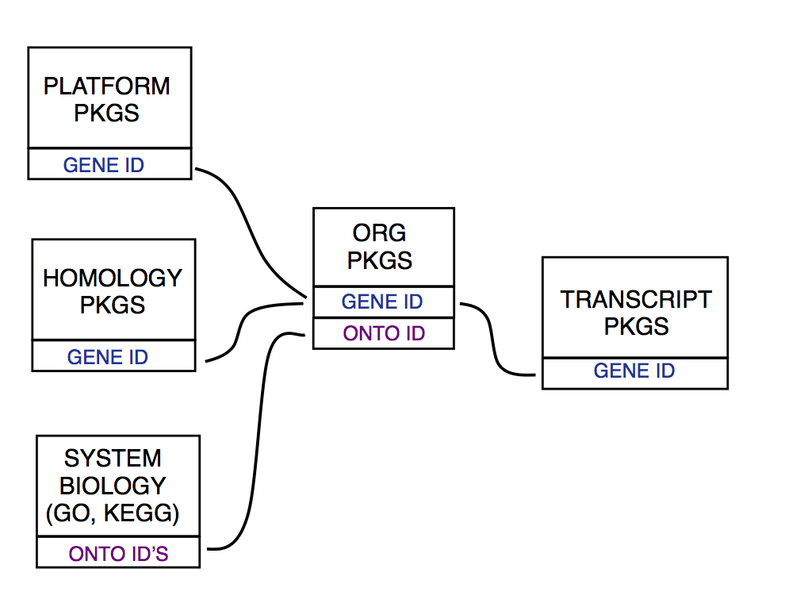

Annotation Packages: the big picture

Here, we will focus on the Genome-centric type of approaches using the GenomicFeatures package.

## Genome-centric annotations with `GenomicFeatures`

Genome-centric packages are very useful for annotations involving genomic coordinates. It is straight-forward, for instance, to discover the coordinates of coding sequences in regions of interest, and from these retrieve corresponding DNA or protein coding sequences. Other examples of the types of operations that are easy to perform with genome-centric annotations include defining regions of interest for counting aligned reads in RNA-seq experiments and retrieving DNA sequences underlying regions of interest in ChIP-seq analysis, e.g., for motif characterization.

- Load the ‘transcript.db’ package relevant to the dm3 build of *D. melanogaster*.
- Use `select` and friends to select the Flybase gene ids of the top table and the Flybase transcript names (TXNAME) and Entrez gene identifiers (GENEID).
- Use `cdsBy` to extract all coding sequences, grouped by transcript.
- Subset the coding sequences to contain just the transcripts relevant to the top table.
- How many transcripts are there?
- What is the structure of the first transcript’s coding sequence?
- Load the ‘BSgenome’ package for the dm3 build of *D. melanogaster*.
- Use the coding sequences ranges of the previous part of this exercise to extract the underlying DNA sequence, using the `extractTranscriptSeqs` function.
- Use `Biostrings`’s `translate` function to convert DNA to amino acid sequences.

The following loads the relevant Transcript.db package, and creates a more convenient alias to the `TranscriptDb` instance defined in the package.

```r
    library(TxDb.Dmelanogaster.UCSC.dm3.ensGene)
    txdb <- TxDb.Dmelanogaster.UCSC.dm3.ensGene
```

We can discover available keys (using `keys`) and columns (`columns`) in `txdb`, and then use `select` to retrieve the transcripts associated with each differentially expressed gene. The mapping between gene and transcript is not one-to-one – some genes have more than one transcripts, which is biologically relevant, and some may have none, which might be due to different database versions being used or database cross-references (xref) inconsistancies.

```r
    set.seed(123)
    fbids <- sample(keys(txdb),10,FALSE,)
    txnm <- select(txdb, fbids, "TXNAME", "GENEID")
    nrow(txnm)
```

```
## [1] 17
```

```r
    head(txnm, 3)
```

```
##        GENEID      TXNAME
## 1 FBgn0031701 FBtr0307036
## 2 FBgn0031701 FBtr0079073
## 3 FBgn0053819 FBtr0091823
```

The `TranscriptDb` instances can be queried for data that is more structured than simple data frames, and in particular return `GRanges` or `GRangesList` instances to represent genomic coordinates. These queries are performed using `cdsBy` (coding sequence), `transcriptsBy` (transcripts), , where the function argument `by` specifies how coding sequences or transcripts are grouped. Here we extract the coding sequences grouped by transcript, returning the transcript names, and subset the resulting `GRangesList` to contain just the transcripts of interest to us. The sixth transcript is composed of 8 distinct coding sequence regions.

```r
    cds <- cdsBy(txdb, "tx", use.names=TRUE)[txnm$TXNAME[6]]
    cds[1]
```

```
## GRangesList object of length 1:
## $FBtr0073547
## GRanges object with 8 ranges and 3 metadata columns:
##       seqnames               ranges strand |    cds_id    cds_name
##          <Rle>            <IRanges>  <Rle> | <integer> <character>
##   [1]     chrX [11332696, 11332927]      - |     59110        <NA>
##   [2]     chrX [11331237, 11332272]      - |     59109        <NA>
##   [3]     chrX [11331056, 11331170]      - |     59108        <NA>
##   [4]     chrX [11330808, 11330825]      - |     59107        <NA>
##   [5]     chrX [11329762, 11330429]      - |     59106        <NA>
##   [6]     chrX [11329582, 11329699]      - |     59105        <NA>
##   [7]     chrX [11329416, 11329514]      - |     59104        <NA>
##   [8]     chrX [11327313, 11327450]      - |     59102        <NA>
##       exon_rank
##       <integer>
##   [1]         2
##   [2]         3
##   [3]         4
##   [4]         5
##   [5]         6
##   [6]         7
##   [7]         8
##   [8]         9
##
## -------
## seqinfo: 15 sequences (1 circular) from dm3 genome
```

The following code loads the appropriate BSgenome package; the object refers to the whole genome sequence represented in this package. The remaining steps extract the DNA sequence of each transcript, and translates these to amino acid sequences. Issues of strand are handled correctly.

```r
    library(BSgenome.Dmelanogaster.UCSC.dm3)
    txx <- extractTranscriptSeqs(Dmelanogaster, cds)
    length(txx)
```

```
## [1] 1
```

```r
    head(txx, 3)
```

```
##   A DNAStringSet instance of length 1
##     width seq                                          names
## [1]  2424 ATGACCCTGACCACAACGACC...GTACGGAGCTCTCCACATAA FBtr0073547
```

```r
    head(translate(txx), 3)
```

```
##   A AAStringSet instance of length 1
##     width seq                                          names
## [1]   808 MTLTTTTTASSAESQAKMDVK...EIDFNDLNMVRRGSTELST* FBtr0073547
```

### Time for Socrative question number 6

## Creating a synthetic set of transcripts

One major caveat estimating gene expression using aligned RNA-Seq reads is that a single read, which originated from a single mRNA molecule, can be aligned to several features ( transcripts or genes) if those alignments are of equivalent quality. This happens as a result of gene duplication and the presence of repetitive or common domains, for example. To avoid this, it is best practice to adopt a conservative approach by collapsing all existing transcripts of a single gene locus into a “synthetic” transcript containing every exon of that gene. In the case of overlapping exons, the longest genomic interval is kept, *i.e.* an artificial exon is created. This process results in a flattened transcript-gene structure with a one to one relationship. As this procedure varies from organism to organism, there is, to the best of our knowledge, no tool available for performing this step.

Here, we will inspire ourselves (ha-ha) from the documentation of the R/Bioconductor easyRNASeq package (Delhomme et al. 2012); paragraph 7.1 of the package vignette.

First, we load the necessary libraries

```r
library(IRanges)
library(genomeIntervals)
```

Next, we read in the GFF3 file

```r
gff <- readGff3(file.path(extdata(),
                          "GFF3/Ptrichocarpa_v3.0_210_gene_exons.gff3.gz"),
                quiet=TRUE)
```

### Time for Socrative question number 7

And have a look at the Genome_Intervals object content

```r
gff
```

```
## Object of class Genome_intervals_stranded
## 1150406 base intervals and 0 inter-base intervals(*):
## Chr01 - [1660, 2502]
## Chr01 - [1660, 2502]
## Chr01 - [1660, 2502]
## Chr01 - [1660, 2502]
## ... 1150398 other intervals...
## scaffold_991 + [13343, 13510]
## scaffold_991 + [13343, 13510]
## scaffold_991 + [13881, 14048]
## scaffold_991 + [13881, 14048]
##
## annotation:
##   seq_name strand inter_base       source type score phase
## 1    Chr01      -      FALSE phytozome9_0 gene    NA    NA
## 2    Chr01      -      FALSE phytozome9_0 mRNA    NA    NA
## 3    Chr01      -      FALSE phytozome9_0 exon    NA    NA
## 4    Chr01      -      FALSE phytozome9_0  CDS    NA     0
##                                                                              gffAttributes
## 1                                                ID=Potri.001G000100;Name=Potri.001G000100
## 2 ID=PAC:27043735;Name=Potri.001G000100.1;pacid=27043735;longest=1;Parent=Potri.001G000100
## 3                                ID=PAC:27043735.exon.1;Parent=PAC:27043735;pacid=27043735
## 4                                 ID=PAC:27043735.CDS.1;Parent=PAC:27043735;pacid=27043735
## ... 1150398 other intervals...
##             seq_name strand inter_base       source type score phase
## 1150403 scaffold_991      +      FALSE phytozome9_0 exon    NA    NA
## 1150404 scaffold_991      +      FALSE phytozome9_0  CDS    NA     0
## 1150405 scaffold_991      +      FALSE phytozome9_0 exon    NA    NA
## 1150406 scaffold_991      +      FALSE phytozome9_0  CDS    NA     0
##                                                     gffAttributes
## 1150403 ID=PAC:26993235.exon.4;Parent=PAC:26993235;pacid=26993235
## 1150404  ID=PAC:26993235.CDS.4;Parent=PAC:26993235;pacid=26993235
## 1150405 ID=PAC:26993235.exon.5;Parent=PAC:26993235;pacid=26993235
## 1150406  ID=PAC:26993235.CDS.5;Parent=PAC:26993235;pacid=26993235
```

```r
nrow(gff[gff$type=="exon",])
```

```
## [1] 460072
```

```r
nrow(gff[gff$type=="mRNA",])
```

```
## [1] 73013
```

```r
nrow(gff[gff$type=="gene",])
```

```
## [1] 41335
```

### Time for Socrative question number 8

Here, we do not ask you to understand every detail of the implementation, but rather to get an idea of the process.

First, we identify the ID and Parents of all mRNA features and create a mapping table from it.

```r
sel <- gff$type == "mRNA"
transcriptGeneMapping <- data.frame(getGffAttribute(gff[sel], "ID"),
                                    getGffAttribute(gff[sel], "Parent")
)
head(transcriptGeneMapping)
```

```
##             ID           Parent
## 1 PAC:27043735 Potri.001G000100
## 2 PAC:27045395 Potri.001G000200
## 3 PAC:27045442 Potri.001G000300
## 4 PAC:27046907 Potri.001G000400
## 5 PAC:27046908 Potri.001G000400
## 6 PAC:27046909 Potri.001G000400
```

Next, we select the exon features and sort them in “groups” by their `Parent`.

```r
sel <- gff$type=="exon"
rngList<- split(IRanges(start=gff[sel,1],end=gff[sel,2]),
                transcriptGeneMapping[match(
                  sapply(strsplit(getGffAttribute(gff[sel,],"Parent"),","),"[",1),
                  transcriptGeneMapping$ID),"Parent"])
rngList
```

```
## IRangesList of length 41335
## $Potri.001G000100
## IRanges object with 1 range and 0 metadata columns:
##           start       end     width
##       <integer> <integer> <integer>
##   [1]      1660      2502       843
##
## $Potri.001G000200
## IRanges object with 3 ranges and 0 metadata columns:
##           start       end     width
##       <integer> <integer> <integer>
##   [1]      6501      6646       146
##   [2]      3506      3928       423
##   [3]      2906      3475       570
##
## $Potri.001G000300
## IRanges object with 1 range and 0 metadata columns:
##           start       end     width
##       <integer> <integer> <integer>
##   [1]      8391      8860       470
##
## ...
## <41332 more elements>
```

```r
mostExons <- rev(names(table(elementNROWS(rngList))))[1]
mostExons
```

```
## [1] "659"
```

### Time for Socrative question number 9

Then, we reduce the exon structure

```r
rngList<- IRanges::reduce(rngList)
rngList
```

```
## IRangesList of length 41335
## $Potri.001G000100
## IRanges object with 1 range and 0 metadata columns:
##           start       end     width
##       <integer> <integer> <integer>
##   [1]      1660      2502       843
##
## $Potri.001G000200
## IRanges object with 3 ranges and 0 metadata columns:
##           start       end     width
##       <integer> <integer> <integer>
##   [1]      2906      3475       570
##   [2]      3506      3928       423
##   [3]      6501      6646       146
##
## $Potri.001G000300
## IRanges object with 1 range and 0 metadata columns:
##           start       end     width
##       <integer> <integer> <integer>
##   [1]      8391      8860       470
##
## ...
## <41332 more elements>
```

```r
rev(names(table(elementNROWS(rngList))))[1]
```

```
## [1] "77"
```

### Time for Socrative question number 10

Once we have reduced the transcript complexity, we can reconstruct a GFF structure from it.

First, we get the gff information; here we simply duplicate the first exon of every gene by the number of synthetic exons per gene. The content will be updated afterwards.

```r
exons <- gff[sel,]
syntheticGeneModel<- exons[rep(
  match(names(rngList),
        transcriptGeneMapping[
          match(sapply(strsplit(getGffAttribute(exons,"Parent"),","),"[",1),
                transcriptGeneMapping$ID),"Parent"]),
  elementNROWS(rngList)),]
```

Then, we update the coordinates, and change the source. This latter step is to document our changes; *i.e.* to make it obvious to anyone using that the newly generated annotation are not the original ones.

```r
syntheticGeneModel[,1]<- unlist(start(rngList))
syntheticGeneModel[,2]<- unlist(end(rngList))
levels(syntheticGeneModel$source)<- "inhouse"
```

Next, we get the exon number for both strands. As the exons are correctly ordered on the minus strands by our first command - *i.e.* in decreasing order, we have to revert those on the plus strand.

```r
exonNumber<- lapply(elementNROWS(rngList),":",1)
sel<- strand(syntheticGeneModel)[cumsum(elementNROWS(rngList))] == "+"
exonNumber[sel]<- sapply(exonNumber[sel],rev)
```

This is followed by the attributes (the ninth column) update.

```r
syntheticGeneModel$gffAttributes<- paste("ID=",
                                         rep(names(rngList),elementNROWS(rngList)),
                                         ":",unlist(exonNumber),";Parent=",
                                         rep(names(rngList),elementNROWS(rngList)),".0",sep="")
```

Before, eventually writing the newly generated annotation in different formats.

```r
writeGff3(syntheticGeneModel,file="~/Ptrichocarpa_v3.0_210_synthetic_transcripts.gff3")

sel <- syntheticGeneModel$type=="exon"
annot <- split(GRanges(seqnames=seq_name(syntheticGeneModel[sel]),
                       ranges=IRanges(start=syntheticGeneModel[sel,1],
                                      end=syntheticGeneModel[sel,2]),
                       strand=strand(syntheticGeneModel[sel])),
               getGffAttribute(syntheticGeneModel,"Parent")[sel,1]
)
save(annot,file="~/Ptrichocarpa_v3.0_210_synthetic_transcripts.rda")
```

### Time for Socrative question number 11

### Alternative

**Note: The same can actually be done with a single call to the “easyRNASeq” “createSyntheticTranscripts” function**

```r
synthTrx <- createSyntheticTranscripts(
    file.path(extdata(),"GFF3/Ptrichocarpa_v3.0_210_gene_exons.gff3.gz"),
    verbose=FALSE)
```

# References

Delhomme, Nicolas, Ismaël Padioleau, Eileen E. Furlong, and Lars M. Steinmetz. 2012. “EasyRNASeq: A Bioconductor Package for Processing Rna-Seq Data.” *Bioinformatics* in press: in press. doi:10.1093/bioinformatics/bts477.